# ECON6027: Assignment 2 (50 marks)

For this homework, use the Columbus, OH crime dataset introduced by Luc Anselin. This is one of the celebrated pioneering datasets, that justified the use of spatial regression models to the literature.

Submission: html output and R code

```r
library(spdep); library(spatialreg); library(sf); library(tmap)
```

To load the dataset (and gal file) directly, run:

`data(columbus, package="spData")`

To load the shapefile (useful for maps), run:

```r
columbus = st_read(system.file("shapes/columbus.shp", package="spData"))
```

To load the gal file, run:

```r
col.gal.nb = read.gal(system.file("weights/columbus.gal", package="spData"))
```

##### When conducting model selection, it is better to have more than one line of arguments supporting your decision (AIC, BIC, R-square, tests, etc.)

1. OLS1: Fit the variable CRIME on HOVAL, INC, OPEN, PLUMB, and DISCBD. Report the summary. (2 marks)

##### Main variables:

- HOVAL: housing value (in $1,000)
- INC: household income (in $1,000)
- CRIME: residential burglaries and vehicle thefts per 1000 households
- OPEN: open space (area)
- PLUMB: percent housing units without plumbing
- DISCBD: distance to CBD

```r
ols1 = lm(CRIME ~ HOVAL+INC+OPEN+PLUMB+DISCBD, data = columbus)
summary(ols1)
```

```
##
## Call:
## lm(formula = CRIME ~ HOVAL + INC + OPEN + PLUMB + DISCBD, data = columbus)
##
## Residuals:
##     Min      1Q  Median      3Q     Max
## -32.869  -6.951   0.311   6.050  18.036
##
## Coefficients:
##             Estimate Std. Error t value Pr(>|t|)
## (Intercept) 67.37126    4.82906  13.951  < 2e-16 ***
## HOVAL       -0.22286    0.10006  -2.227  0.03122 *
## INC         -0.99057    0.33006  -3.001  0.00446 **
## OPEN         0.09976    0.32478   0.307  0.76021
## PLUMB        0.61355    0.48674   1.261  0.21428
## DISCBD      -3.91437    1.61013  -2.431  0.01930 *
## ---
## Signif. codes:  0 '***' 0.001 '**' 0.01 '*' 0.05 '.' 0.1 ' ' 1
##
## Residual standard error: 9.903 on 43 degrees of freedom
## Multiple R-squared:  0.6862, Adjusted R-squared:  0.6497
## F-statistic: 18.81 on 5 and 43 DF,  p-value: 7.193e-10
```

2. OLS2: (nested): Fit the variable CRIME only on HOVAL and INC. Report the summary. (2 marks)

```r
ols2 = lm(CRIME ~ HOVAL+INC, data = columbus)
summary(ols2)
```

```
##
## Call:
## lm(formula = CRIME ~ HOVAL + INC, data = columbus)
##
## Residuals:
##     Min      1Q  Median      3Q     Max
## -34.418  -6.388  -1.580   9.052  28.649
##
## Coefficients:
##             Estimate Std. Error t value Pr(>|t|)
## (Intercept)  68.6190     4.7355  14.490  < 2e-16 ***
## HOVAL        -0.2739     0.1032  -2.654   0.0109 *
## INC          -1.5973     0.3341  -4.780 1.83e-05 ***
## ---
## Signif. codes:  0 '***' 0.001 '**' 0.01 '*' 0.05 '.' 0.1 ' ' 1
##
## Residual standard error: 11.43 on 46 degrees of freedom
## Multiple R-squared:  0.5524, Adjusted R-squared:  0.5329
## F-statistic: 28.39 on 2 and 46 DF,  p-value: 9.341e-09
```

3. Determine which model is a better fit for CRIME. Explain. (3 marks)

```r
AIC(ols1); AIC(ols2)
```

```
## [1] 371.3489
```

```
## [1] 382.7545
```

```r
BIC(ols1); BIC(ols2)
```

```
## [1] 384.5917
```

```
## [1] 390.3218
```

```r
# Based on AIC and adjusted $R$-square, OLS1 is a better fit for CRIME.
# However, the individual $t$-stats for variables PLUMB and OPEN are not significant suggesting the appropriateness of the nested model overall.
```

4. At 5% level of significance, test whether the nested model (OLS2) suffers from non-normality of errors and heteroskedasticity of errors. (4 marks)

```r
lmtest::bptest(ols2)
```

```
##
##  studentized Breusch-Pagan test
##
## data:  ols2
## BP = 7.2166, df = 2, p-value = 0.0271
```

```r
# Reject the null of homoskedasticity.
# Evidence of heteroskedasticity at 5% level.

tseries::jarque.bera.test(ols2$residuals)
```

```
##
##  Jarque Bera Test
##
## data:  ols2$residuals
## X-squared = 1.8358, df = 2, p-value = 0.3994
```

```r
# Do not reject the null of normality.
# No evidence of non-normality of residuals at 5% level.
```

5. Plot the CRIME, HOVAL and INC values on three different maps of Columbus. What spatial relationships do you observe? (6 marks)

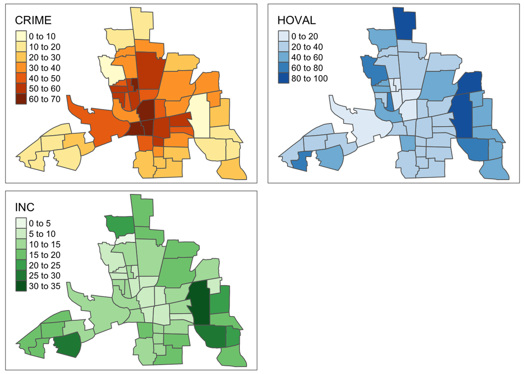

```r
crime_map = tm_shape(columbus) + tm_polygons(col="CRIME")
hoval_map = tm_shape(columbus) + tm_polygons(col="HOVAL", palette="Blues")
inc_map = tm_shape(columbus) + tm_polygons(col="INC", palette="Greens")
tmap_arrange(crime_map, hoval_map, inc_map)
```

```r
# There is a clear spatial concentration of CRIME in the central region of Columbus.
# Spatial concentration of the other two variables are less clear.
# However, notice how similar coloured polygons seem to gather together suggesting positive spatial autocorrelation.
# In particular, HOVAL and INC seem to be higher in the North, East and South East regions.
```

6. Conduct Moran’s tests on the variables in the nested model (OLS2) to detect any spatial autocorrelation. Report your conclusions at 5% level of significance. (6 marks)

```r
wlist = nb2listw(col.gal.nb, style="W")
moran.test(columbus$CRIME, wlist)
```

```
##
##  Moran I test under randomisation
##
## data:  columbus$CRIME
## weights: wlist
##
## Moran I statistic standard deviate = 5.3427, p-value = 4.578e-08
## alternative hypothesis: greater
## sample estimates:
## Moran I statistic       Expectation          Variance
##       0.485770914      -0.020833333       0.008991121
```

```r
moran.test(columbus$HOVAL, wlist)
```

```
##
##  Moran I test under randomisation
##
## data:  columbus$HOVAL
## weights: wlist
##
## Moran I statistic standard deviate = 2.1001, p-value = 0.01786
## alternative hypothesis: greater
## sample estimates:
## Moran I statistic       Expectation          Variance
##       0.173645208      -0.020833333       0.008575953
```

```r
moran.test(columbus$INC, wlist)
```

```
##
##  Moran I test under randomisation
##
## data:  columbus$INC
## weights: wlist
##
## Moran I statistic standard deviate = 4.6967, p-value = 1.322e-06
## alternative hypothesis: greater
## sample estimates:
## Moran I statistic       Expectation          Variance
##        0.41683794       -0.02083333        0.00868364
```

```r
# Reject the null of no spatial autocorrelation in all three variables at 5% level.
# All variables display significant spatial spillover effects at 5% level.
```

7. Are there any “residual” spill-over effects in the nested model? (2 marks)

```r
lm.morantest(ols2, wlist)
```

```
##
##  Global Moran I for regression residuals
##
## data:
## model: lm(formula = CRIME ~ HOVAL + INC, data = columbus)
## weights: wlist
##
## Moran I statistic standard deviate = 2.681, p-value = 0.00367
## alternative hypothesis: greater
## sample estimates:
## Observed Moran I      Expectation         Variance
##      0.212374153     -0.033268284      0.008394853
```

```r
# Reject the null of no spatial autocorrelation in the OLS2 residuals.
# Evidence of significant spatial autocorrelation in the residuals of model 2 and the dependent variable at 5% level.
```

8. Fit CRIME on the usual spatial regression models and report your results. (4 marks)

```r
sar = spautolm(CRIME ~ 1, columbus, wlist)
slm = lagsarlm(CRIME ~ HOVAL+INC, columbus, wlist)
sem = errorsarlm(CRIME ~ HOVAL+INC, columbus, wlist)
sarar = sacsarlm(CRIME ~ HOVAL+INC, columbus, wlist)

summary(sar)
```

```
##
## Call: spautolm(formula = CRIME ~ 1, data = columbus, listw = wlist)
##
## Residuals:
##      Min       1Q   Median       3Q      Max
## -44.6085  -7.2157  -2.0908   9.4960  26.9256
##
## Coefficients:
##             Estimate Std. Error z value  Pr(>|z|)
## (Intercept)  35.5946     5.1989  6.8466 7.561e-12
##
## Lambda: 0.65037 LR test value: 19.666 p-value: 9.2233e-06
## Numerical Hessian standard error of lambda: 0.11479
##
## Log likelihood: -197.239
## ML residual variance (sigma squared): 161.89, (sigma: 12.724)
## Number of observations: 49
## Number of parameters estimated: 3
## AIC: 400.48
```

```r
summary(slm)
```

```
##
## Call:lagsarlm(formula = CRIME ~ HOVAL + INC, data = columbus, listw = wlist)
##
## Residuals:
##         Min          1Q      Median          3Q         Max
## -37.4497093  -5.4565567   0.0016387   6.7159553  24.7107978
##
## Type: lag
## Coefficients: (asymptotic standard errors)
##              Estimate Std. Error z value  Pr(>|z|)
## (Intercept) 46.851431   7.314754  6.4051 1.503e-10
## HOVAL       -0.269997   0.090128 -2.9957 0.0027381
## INC         -1.073533   0.310872 -3.4533 0.0005538
##
## Rho: 0.40389, LR test value: 8.4179, p-value: 0.0037154
## Asymptotic standard error: 0.12071
##     z-value: 3.3459, p-value: 0.00082027
## Wald statistic: 11.195, p-value: 0.00082027
##
## Log likelihood: -183.1683 for lag model
## ML residual variance (sigma squared): 99.164, (sigma: 9.9581)
## Number of observations: 49
## Number of parameters estimated: 5
## AIC: 376.34, (AIC for lm: 382.75)
## LM test for residual autocorrelation
## test value: 0.19184, p-value: 0.66139
```

```r
summary(sem)
```

```
##
## Call:
## errorsarlm(formula = CRIME ~ HOVAL + INC, data = columbus, listw = wlist)
##
## Residuals:
##       Min        1Q    Median        3Q       Max
## -34.45950  -6.21730  -0.69775   7.65256  24.23631
##
## Type: error
## Coefficients: (asymptotic standard errors)
##              Estimate Std. Error z value  Pr(>|z|)
## (Intercept) 61.053618   5.314875 11.4873 < 2.2e-16
## HOVAL       -0.307979   0.092584 -3.3265 0.0008794
## INC         -0.995473   0.337025 -2.9537 0.0031398
##
## Lambda: 0.52089, LR test value: 6.4441, p-value: 0.011132
## Asymptotic standard error: 0.14129
##     z-value: 3.6868, p-value: 0.00022713
## Wald statistic: 13.592, p-value: 0.00022713
##
## Log likelihood: -184.1552 for error model
## ML residual variance (sigma squared): 99.98, (sigma: 9.999)
## Number of observations: 49
## Number of parameters estimated: 5
## AIC: 378.31, (AIC for lm: 382.75)
```

```r
summary(sarar)
```

```
##
## Call:sacsarlm(formula = CRIME ~ HOVAL + INC, data = columbus, listw = wlist)
##
## Residuals:
##      Min       1Q   Median       3Q      Max
## -37.1121  -4.6324  -0.3040   7.0306  24.6929
##
## Type: sac
## Coefficients: (asymptotic standard errors)
##              Estimate Std. Error z value Pr(>|z|)
## (Intercept) 49.051430  10.054986  4.8783 1.07e-06
## HOVAL       -0.283114   0.091526 -3.0933 0.001980
## INC         -1.068781   0.332839 -3.2111 0.001322
##
## Rho: 0.35326
## Asymptotic standard error: 0.19669
##     z-value: 1.796, p-value: 0.072494
## Lambda: 0.13199
## Asymptotic standard error: 0.29905
##     z-value: 0.44138, p-value: 0.65894
##
## LR test value: 8.6082, p-value: 0.013513
##
## Log likelihood: -183.0731 for sac model
## ML residual variance (sigma squared): 99.423, (sigma: 9.9711)
## Number of observations: 49
## Number of parameters estimated: 6
## AIC: 378.15, (AIC for lm: 382.75)
```

1. Use the LM test to determine whether the SLM model or the SEM model is a better fit for the data. (4 marks)

```r
lm.LMtests(ols2, listw=wlist, test="RLMerr")
```

```
## Please update scripts to use lm.RStests in place of lm.LMtests
```

```
##
##  Rao's score (a.k.a Lagrange multiplier) diagnostics for spatial
##  dependence
##
## data:
## model: lm(formula = CRIME ~ HOVAL + INC, data = columbus)
## test weights: listw
##
## adjRSerr = 0.033514, df = 1, p-value = 0.8547
```

```r
lm.LMtests(ols2, listw=wlist, test="RLMlag")
```

```
## Please update scripts to use lm.RStests in place of lm.LMtests
```

```
##
##  Rao's score (a.k.a Lagrange multiplier) diagnostics for spatial
##  dependence
##
## data:
## model: lm(formula = CRIME ~ HOVAL + INC, data = columbus)
## test weights: listw
##
## adjRSlag = 3.2781, df = 1, p-value = 0.07021
```

```r
# Both non-robust tests are significant at 5% level.
# However, both robust tests are not significant at 5% level.
# Comparison of the p-values suggests the SLM is more likely.
```

[output not shown]

[output not shown]

10. Use the likelihood ratio test to determine whether:
1. SARAR(1,1) model is superior to SLM or SEM (4 marks)

```r
LR.Sarlm(sem,sarar) # SEM vs SARAR
```

```
##
##  Likelihood ratio for spatial linear models
##
## data:
## Likelihood ratio = -2.1642, df = 1, p-value = 0.1413
## sample estimates:
##   Log likelihood of sem Log likelihood of sarar
##               -184.1552               -183.0731
```

```r
LR.Sarlm(slm,sarar) # SLM vs SARAR
```

```
##
##  Likelihood ratio for spatial linear models
##
## data:
## Likelihood ratio = -0.19031, df = 1, p-value = 0.6627
## sample estimates:
##   Log likelihood of slm Log likelihood of sarar
##               -183.1683               -183.0731
```

```r
# SARAR model is rejected in both tests in favour of SEM and SLM
```

2. SLM model is superior to SAR. (2 marks)

```r
LR.Sarlm(sar,slm) # SAR vs SLM
```

```
##
##  Likelihood ratio for spatial linear models
##
## data:
## Likelihood ratio = -28.141, df = 2, p-value = 7.748e-07
## sample estimates:
## Log likelihood of sar Log likelihood of slm
##             -197.2390             -183.1683
```

```r
# SAR model is rejected in favour of the SLM model.
```

11. Combine the results of (i) and (j) and any other diagnostics and identify the most suitable spatial model. (3 marks)

```r
# Based on the LR tests, the SEM or the SLM is better.
# Robust LM test are somewhat inconclusive although the SLM model has the advantage w.r.t. the p-value.

AIC(slm); AIC(sem)
```

```
## [1] 376.3366
```

```
## [1] 378.3104
```

```r
# Further, the AIC for the SLM is smaller compared to the AIC for the SEM suggesting the superiority of the SLM.
# Therefore, overall the SLM is the better option.
```

12. Compare the model selected in (k) to the nested linear model (OLS2) and determine whether the spatial specification is superior to the usual linear regression specification for this dataset. (3 marks)

```r
LR1.Sarlm(slm)
```

```
##
##  Likelihood Ratio diagnostics for spatial dependence
##
## data:
## Likelihood ratio = 8.4179, df = 1, p-value = 0.003715
## sample estimates:
## Log likelihood of spatial lag model         Log likelihood of OLS fit y
##                           -183.1683                           -187.3772
```

```r
# Reject the nested model (OLS2) in favour of the SLM specification at 5% level.
# Furthermore, the AIC of the SLM (376.34) is smaller compared to the AIC of OLS2 (382.75), suggesting that the SLM specification is better.
```

13. Determine whether a higher lag order is more suitable for the model selected in (k). (5 marks)

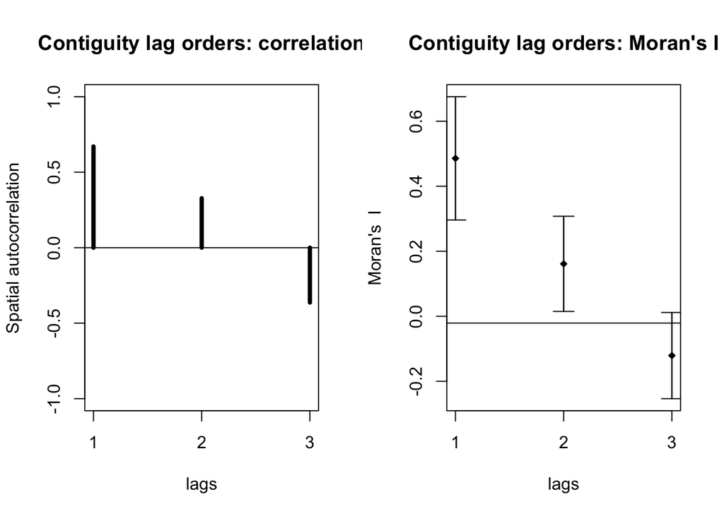

```r
correl = sp.correlogram(neighbours=col.gal.nb, var=columbus$CRIME, order=3, method="corr", style="W")
correlI = sp.correlogram(neighbours=col.gal.nb, var=columbus$CRIME, order=3, method="I", style="W")
par(mfrow=c(1,2))
plot(correl, main="Contiguity lag orders: correlation")
plot(correlI, main="Contiguity lag orders: Moran's I")
```

```r
par(mfrow=c(1,1))
# Based on spatial autocorrelation and Moran's I confidence intervals, a lag order of 2 seems to be appropriate.
```